# DOM Review: Initial analysis

## Summary

This document includes some preliminary analyses of the dynamic occupancy model review results, arranged by the six categories included in the review:

- Study
- Objectives
- Taxa and location
- Survey methods
- Parameters and covariates
- Modelling methods

## Study

Basic information on the locations and affiliations of authors involved with each paper was collected.

### Authorship countries

Two thirds of papers (36/54) were by authors from U.S. institutions; the next greatest total was 3 papers from Australia.

#### Map

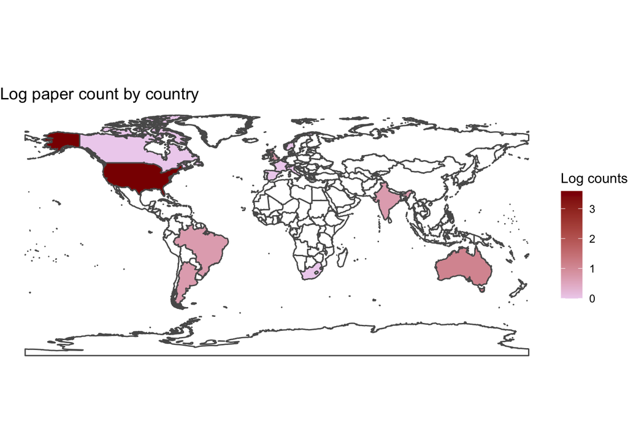

#### Table

| First author country | Total papers |
| --- | --- |
| United States of America | 36 |
| Australia | 3 |
| Argentina | 2 |
| Brazil | 2 |
| India | 2 |
| United Kingdom | 2 |
| Canada | 1 |
| France | 1 |
| Italy | 1 |
| Norway | 1 |
| South Africa | 1 |
| Spain | 1 |
| Switzerland | 1 |

### Authorship affiliations

Affiliated institutions were split into four categories: Academic, Non-governmental organisations, Governmental agencies, and private sector groups. These were fairly varied, with academic groups participating in the vast majority of papers but with substantial representation from governmental and NGO groups.

| Affiliation | % of papers |
| --- | --- |
| Academic | 81.5 |
| Government | 42.6 |
| NGO | 29.6 |
| Private | 7.4 |

## Objectives

Five categories of objectives and goals were assessed for each paper; these were not mutually exclusive and many papers had multiple objectives.

- Assessing trends: interested in the trajectory of estimated or derived parameters
- Testing hypotheses: evaluating attributes of a **specific** covariate on parameters
- Spatial mapping: Extrapolating estimates of parameter values beyond surveyed sites
- Future projections: Making predictions of parameters into the future
- Methods: introducing, testing, or demonstrating a new extension to these models

### Papers per objective

Monitoring trends and testing hypotheses were the most popular objectives; making predictions (spatial or temporal) was quite rare.

| Objective | Percent of papers |
| --- | --- |
| Trends | 72.2 |
| Hypothesis | 55.6 |
| Methods | 18.5 |
| Spatial | 9.3 |
| Projections | 7.4 |

### Objectives by authorship group

Objectives did appear to vary based on whether certain types of authors worked on the paper. Where government or NGO authors were present, papers tended to assess trends moreso than testing hypotheses.

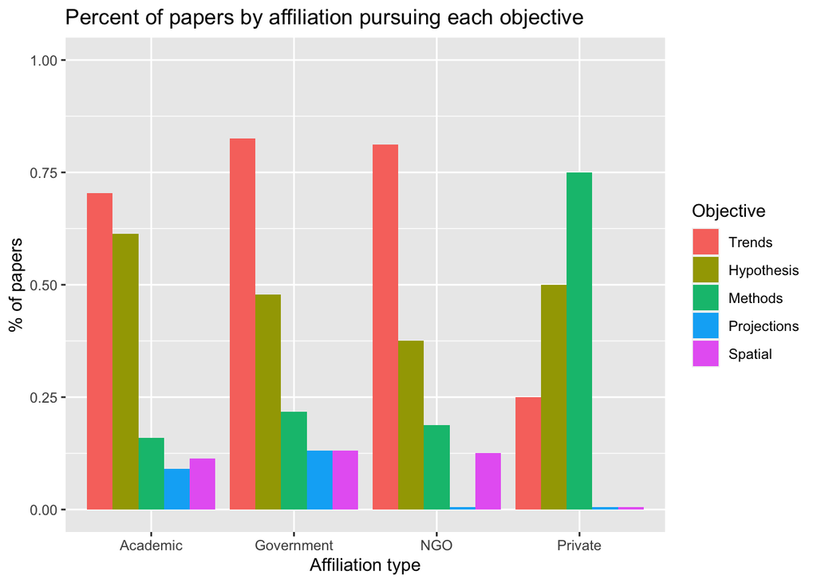

### Covariates by objection

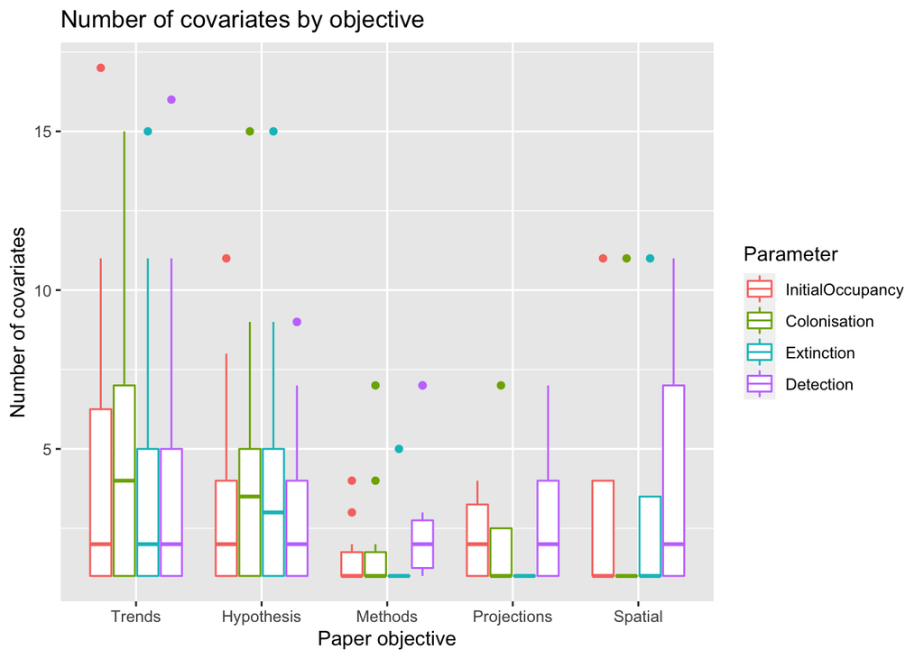

### Selection by objective

*A priori* model selection was the most popular method for each of the five objective categories, with more complex options quite rare. *Note that the model selection data needs to be cleaned a bit more to fix overlapping categories*

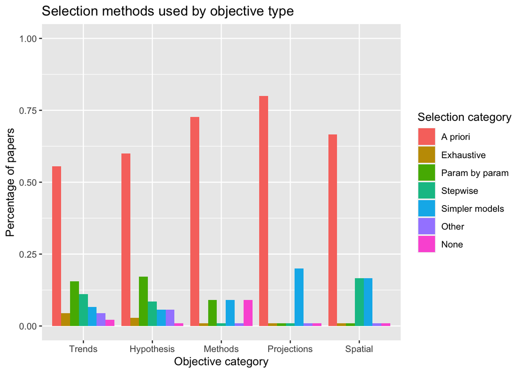

## Taxa and location

Details on the study organism was collected for each study to assess any trends in the types of species these models are applied to, with a particular focus on those that are vulnerable to conservation threats. The locations where surveys were conducted was also noted.

As with authorship, the United States dominated the countries where surveys took place.

### Study site maps

As with authorship, the United States/North America dominated the countries where surveys took place.

#### Country

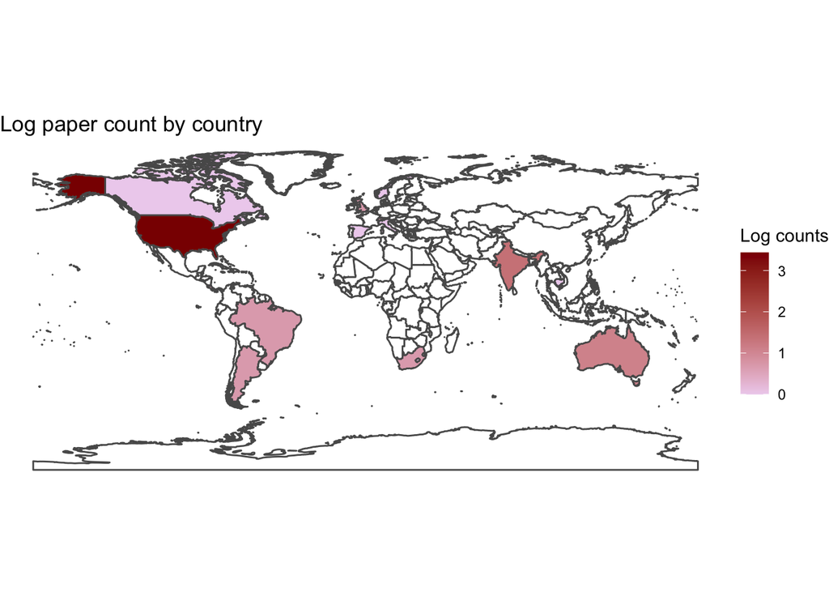

| Country | Total papers |
| --- | --- |
| United States of America | 31 |
| India | 4 |
| Australia | 3 |
| Argentina | 2 |
| Brazil | 2 |
| Costa Rica | 2 |
| South Africa | 2 |
| Switzerland | 2 |
| United Kingdom | 2 |
| Belize | 1 |
| Cambodia | 1 |
| Canada | 1 |
| Eswatini | 1 |
| Italy | 1 |
| Lesotho | 1 |
| Norway | 1 |
| Spain | 1 |

#### Continent

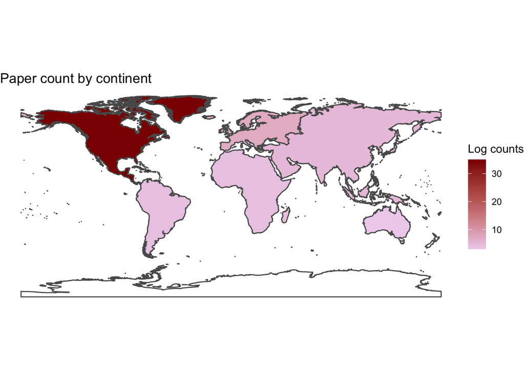

| Continent | Total papers |
| --- | --- |
| North America | 35 |
| Europe | 7 |
| Asia | 5 |
| Africa | 4 |
| South America | 4 |
| Oceania | 3 |

#### Realm

| Realm | Total papers |
| --- | --- |
| Nearctic | 30 |
| Neotropical | 10 |
| Palearctic | 6 |
| Indomalayan | 5 |
| Afrotropical | 4 |
| Australasian | 3 |

### Study species

Taxa were roughly split between mammals, birds, and herptiles; fish and invertebrates were scantly represented. 16 were recognised as threatened species by the authors, and 8 were invasives.

| Taxa | Count |
| --- | --- |
| Mammal | 25 |
| Bird | 24 |
| Herptile | 17 |
| Threatened | 16 |
| Invasive | 8 |
| Invertebrate | 3 |
| Fish | 1 |

### Threat categories

Threats to each species which were mentioned by the author were denoted. Habitat loss was the most common threat mentioned, followed by invasive species.

| Threat | Percent |
| --- | --- |
| HabitatLoss | 41.49 |
| Invasives | 18.09 |
| Exploitation | 8.51 |
| ClimateChange | 6.38 |
| Disease | 2.13 |
| Disaster | 0.00 |

### Study size

Study area followed an apparent log-normal distribution centered on the 100-10000km^2 range

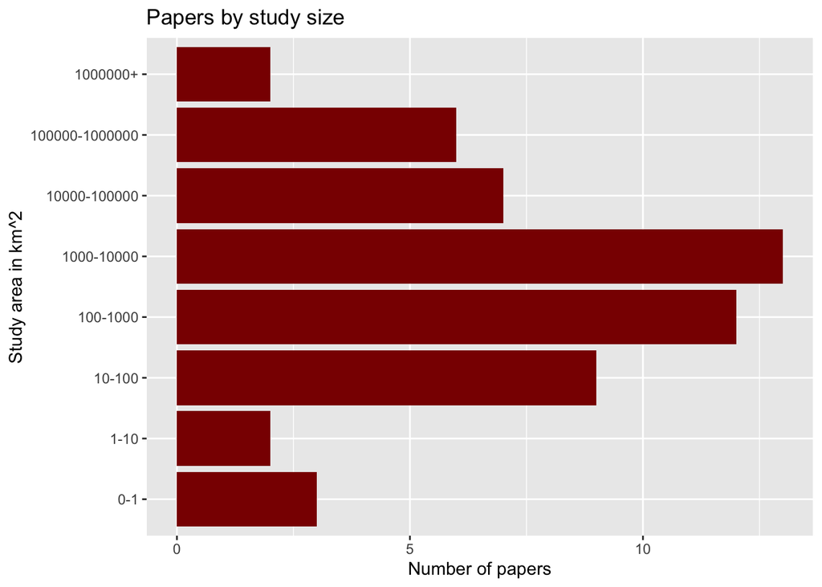

### Covariates by study size

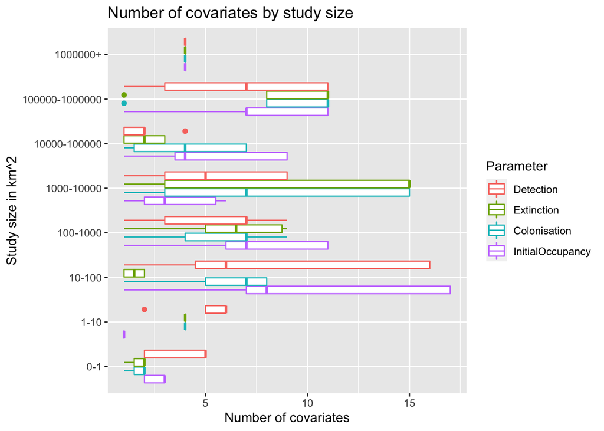

## Survey methods

Information on the data collection and sampling processes was collected from all papers.

### Study duration

Average study length from first to last survey was 83 months (~7 years), although they varied from just one month to 40 years in duration.

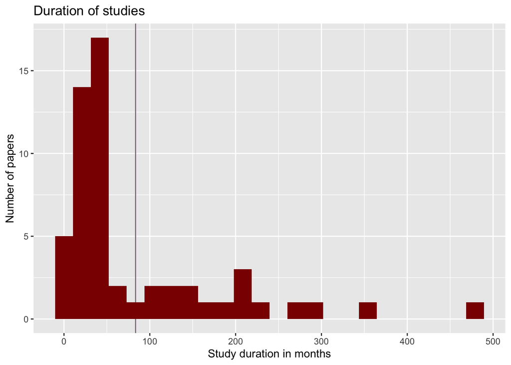

### Sampling occasions

The primary sampling occasion (season) and secondary occasion (generally ‘visit’, used to calculate detection) were recorded. Number of secondary occasions per primary occasion sometimes varied within a study, min and max counts are noted.

#### Primary occasions

The median number of primary occasions from the reviewed studies was *5*, although two outlying studies had over *200* primary occasions.

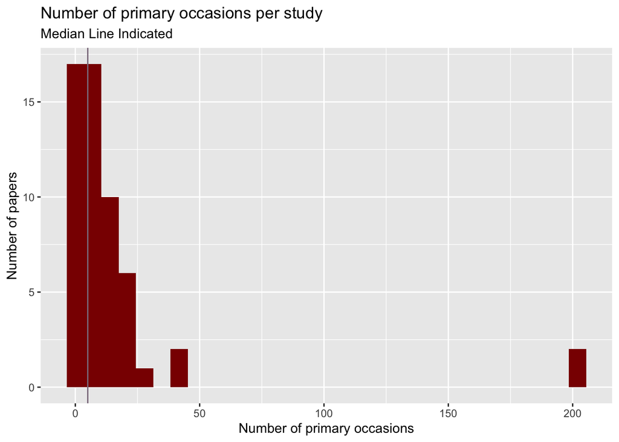

#### Secondary occasions

Studies had a median of *4* secondary occasions, with a maximum of *99*

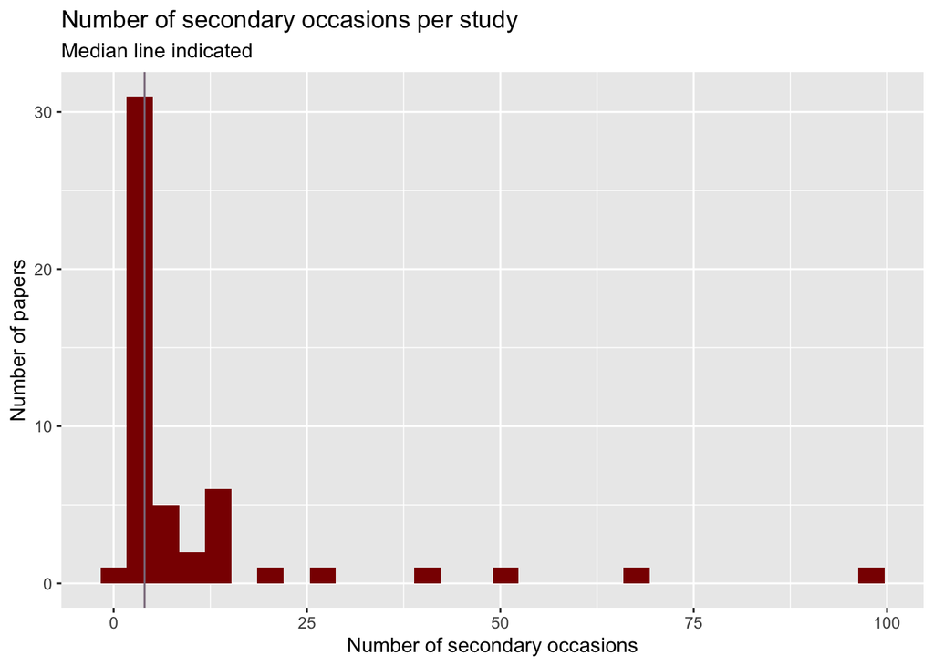

### Capture method

The most common method for detections was ‘audiovisual,’ where human observers visually or acoustically sampled the target taxa in a structured manner (e.g., as a transect or point count). Searches (where the site was preferentially searched for the species) and trapping was also common. Citizen science was involved in 7 papers.

| Capture method | Number of papers |
| --- | --- |
| AudioVisual | 22 |
| Search | 13 |
| Trapping | 12 |
| Camera | 8 |
| Citizen | 7 |
| Bioacoustic | 1 |
| Incidental | 1 |

### Site types

The definition of a ‘site’ (the level of occupied and unoccupied states) was variable. Irregular areas (like habitat patches or ponds) were the most common, followed by cartesian points and grid cells.

| Type site | Number of papers |
| --- | --- |
| Irregular area | 19 |
| Point location | 15 |
| Grid cell | 13 |
| Transect | 6 |
| Other | 2 |

### Number of sites

The number of sites ranged from 7 to 9394, with a mean of *377* sites.

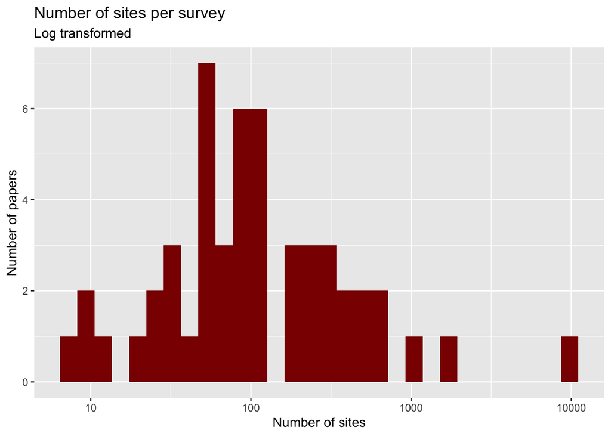

### Number of sites by study size

As would be expected, the number of sites increases with the size of the study area.

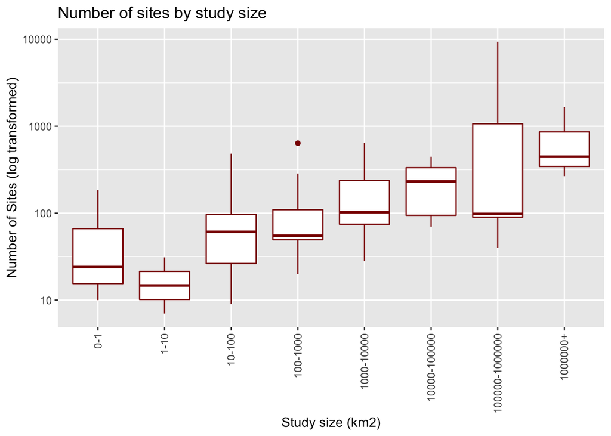

### Covariates by site count

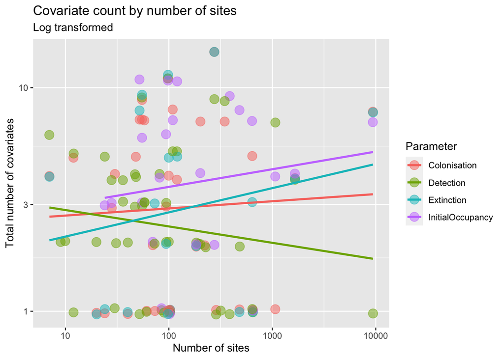

### Sampling method

Methods used to select sites were documented - this section needs to be revisited, as some categories can likely be combined. The most interesting question here may in whether selection falls under a broad ‘random’ or ‘preferential’ system, and how that relates to objectives or covariates.

| Sampling method | Number of papers |
| --- | --- |
| Random | 15 |
| Grid | 13 |
| Preferential | 9 |
| Stratified | 8 |
| Not specified | 7 |
| Unspecified | 7 |
| Exhaustive | 6 |
| Available | 5 |
| Transect | 4 |
| Other | 2 |
| Uniform | 1 |

## Parameters and covariates

The most complex and in-depth category of data was the covariates, which were organised by parameter and covariate type.

### Parameters estimated

The vast majority of papers used the four core parameters of the standard DOM: **Initial occupancy**, **colonisation**, **extinction**, and **detection** (although 12 used the reciprocal of **Extinction**, **Persistence**)

| Parameter | Number of papers | Percentage |
| --- | --- | --- |
| Detection | 54 | 1.0000000 |
| Colonisation | 47 | 0.8703704 |
| InitialOccupancy | 45 | 0.8333333 |
| Extinction | 31 | 0.5740741 |
| Persistence | 12 | 0.2222222 |
| Occupancy | 11 | 0.2037037 |
| Other | 8 | 0.1481481 |

### Multi-species

*9* models included at least one multi-species parameter.

### Covariate types by parameter

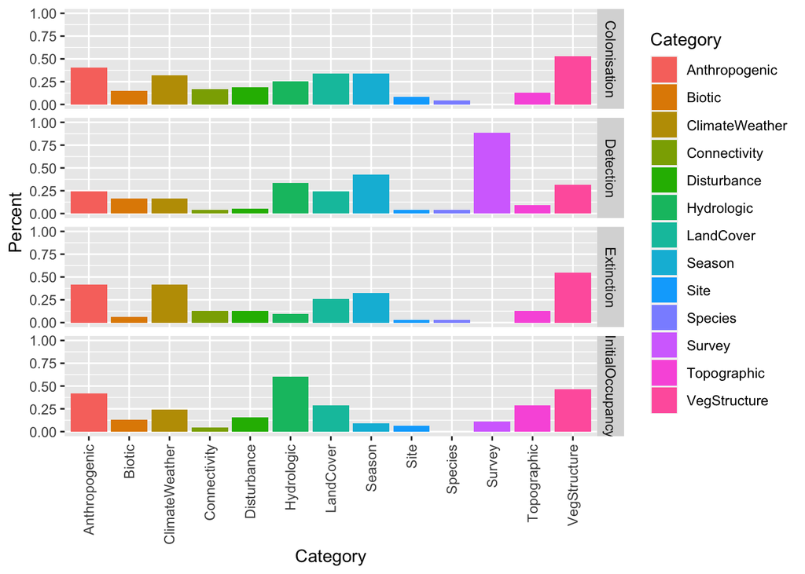

### Number of covariate by parameter

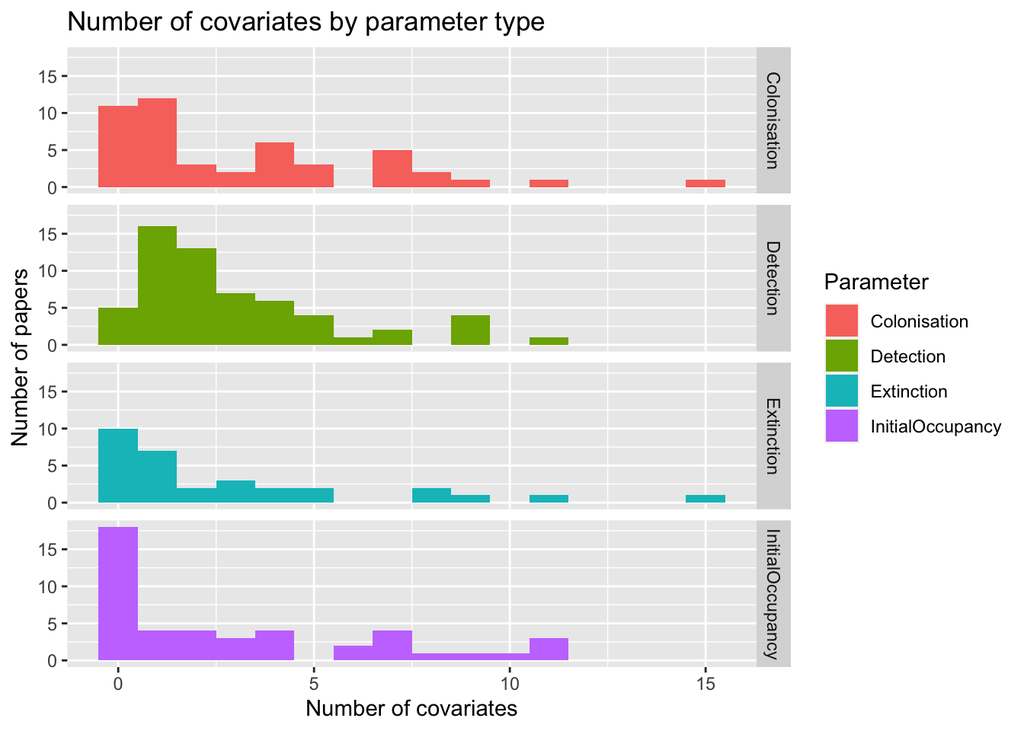

### Dynamicity in covariate types

Covariates varied drastically in whether they were **static** or **dynamic**

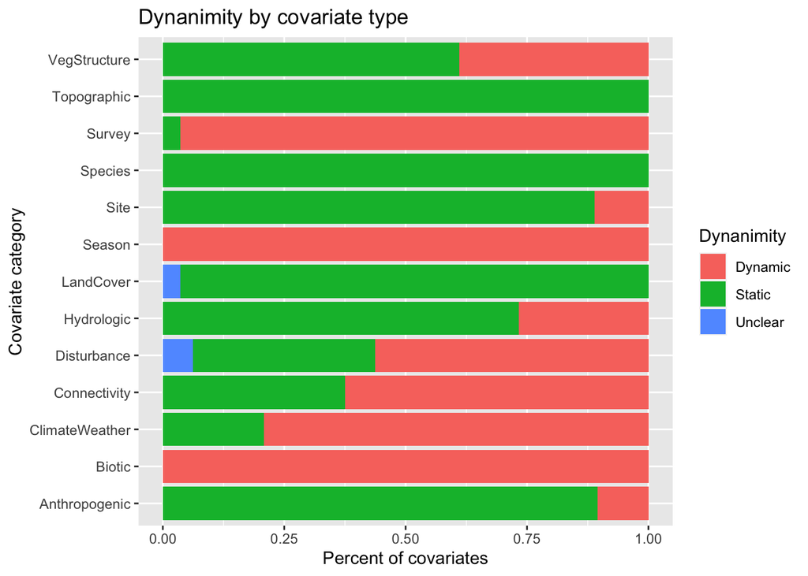

### Covariate scale

‘Scale’ defined as whether the covariate represents a point, area, distance, etc.

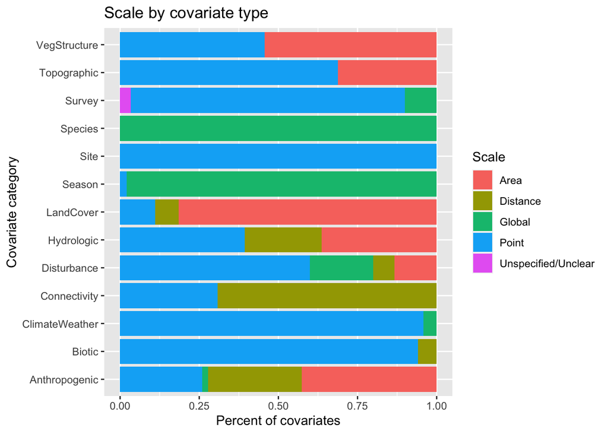

## Modelling decisions

### Selection method

The majority of papers selected models **a priori** (either single or multiple)

| Selection category | Percent |
| --- | --- |
| Apriori | 0.65 |
| PbyP | 0.17 |
| Step | 0.15 |
| Simple | 0.07 |
| Exhaustive | 0.04 |
| None | 0.04 |
| Other | 0.04 |

### Percent bayesian

*41%* of papers used a bayesian implementation

### Bayesian selection methods

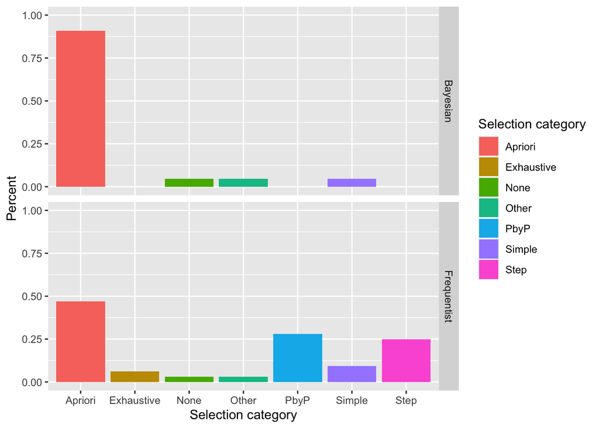